# Task 7_Basic visualization with R

Angela Jennifer Tantry

2026-11-01

To work on this task, firstly, ggplot2 package is loaded.

```r
# Loading ggplot package
library(ggplot2)
```

# 1. Comparing body heights distributions of the two species in magic_guys.csv dataset

The magic_guys.csv dataset is loaded.

```r
# Loading magic_guys.csv dataset
magic_guys <- read.csv("magic_guys.csv")
```

1. Histogram Visualization

## Visualization using basic ‘hist’ function

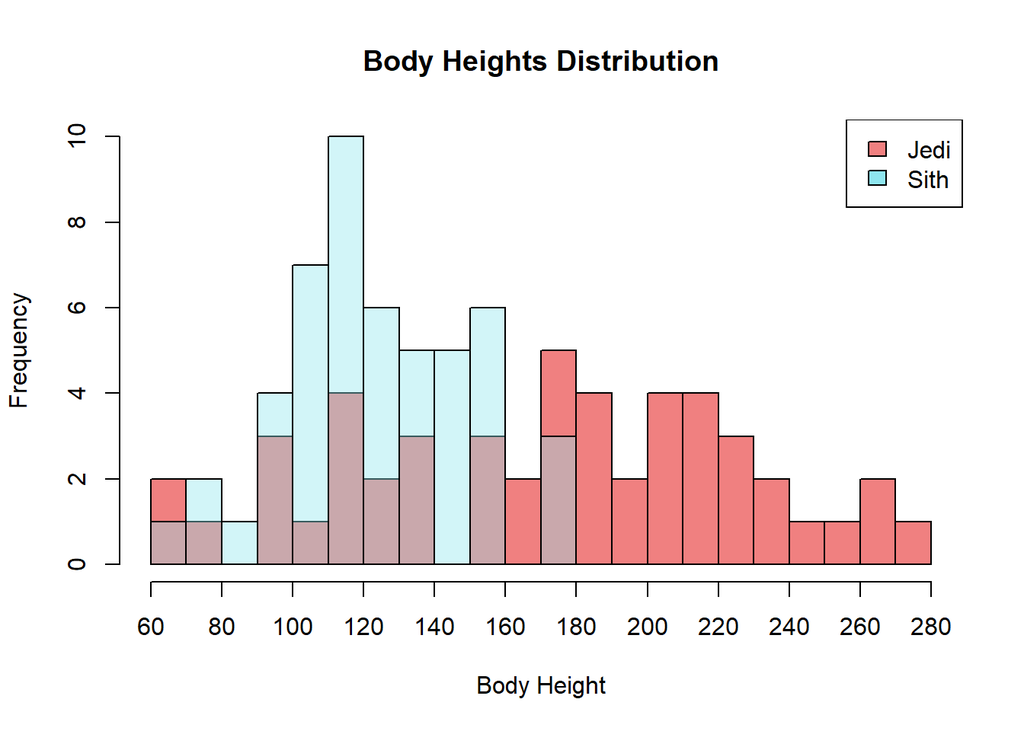

```r
# Calculate shared breaks for histograms from both species
common_breaks <- seq(
  floor(min(magic_guys$length)/10)*10,   # set the minimum value of x-axis to the nearest round number of the minimum data in length
  ceiling(max(magic_guys$length)/10)*10, # set the maximum value of x-axis to the nearest round number of the maximum data in length
  by = 10                                # set the breaks by 10 increments
)

# Make the plot for Jedi species
hist(magic_guys$length[magic_guys$species == "jedi"], # obtain length data of Jedi species
     breaks = common_breaks,                          # set the breaks using previously calculated breaks
     xaxt = "n",                                      # not using default x axis
     xlim = c(60, 280),                               # adjust range of x axis
     ylim = c(0, 10),                                 # adjust range of y axis
     col = "lightcoral",
     main = "Body Heights Distribution",
     xlab = "Body Height",
     ylab = "Frequency")
# Make the plot for Sith species
hist(magic_guys$length[magic_guys$species == "sith"], # obtain length data of Sith species
     breaks = common_breaks,                          # set the breaks using previously calculated breaks
     col = adjustcolor("cadetblue2", alpha.f=0.4),    # opacity adjusted to ensure visibility of both graphs
     add = TRUE)

axis(1, at = seq(60, 280, by = 20))                   # set x axis increments

legend("topright",
       legend = c("Jedi", "Sith"),
       fill = c("lightcoral","cadetblue2"))
```

## Visualization using ‘ggplot’ and ‘geom_histogram’

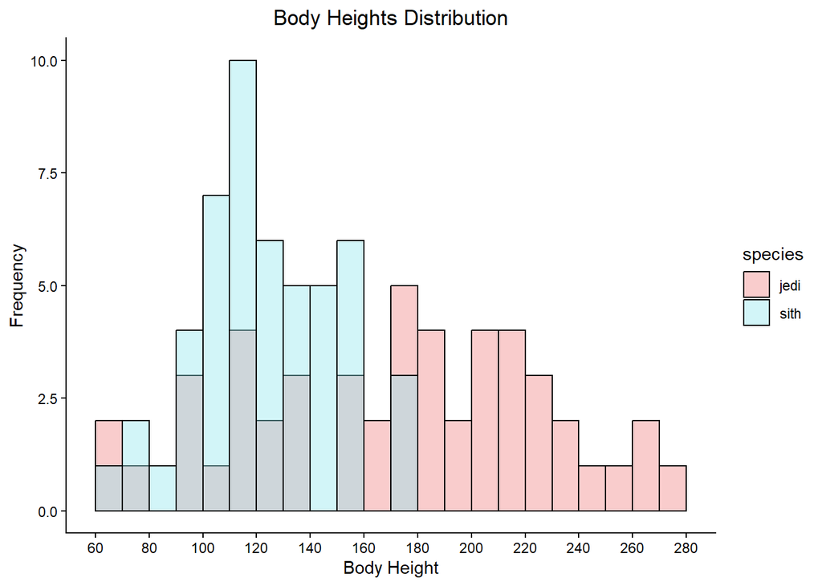

```r
# Make the plot
ggplot(magic_guys, aes(x = length, fill = species)) +
  geom_histogram(
    position = "identity",
    alpha = 0.4,            # adjust opacity
    binwidth = 10,          # make intervals of 10
    boundary = 60,          # set the starting point of interval
    color = "black"
  ) +
  scale_x_continuous(
    breaks = seq(60, 280, by = 20), # set x axis in 20 increments
    limits = c(60, 280)             # set minimum and maximum values of x axis
  ) +
  scale_fill_manual(
    values = c(
      "jedi" = "lightcoral",
      "sith" = "cadetblue2"
    )
  ) +
  labs(
    x = "Body Height",
    y = "Frequency",
    title = "Body Heights Distribution"
  ) +
  theme_classic() +
  theme(
  plot.title = element_text(hjust = 0.5))
```

## b. Boxplot Visualization

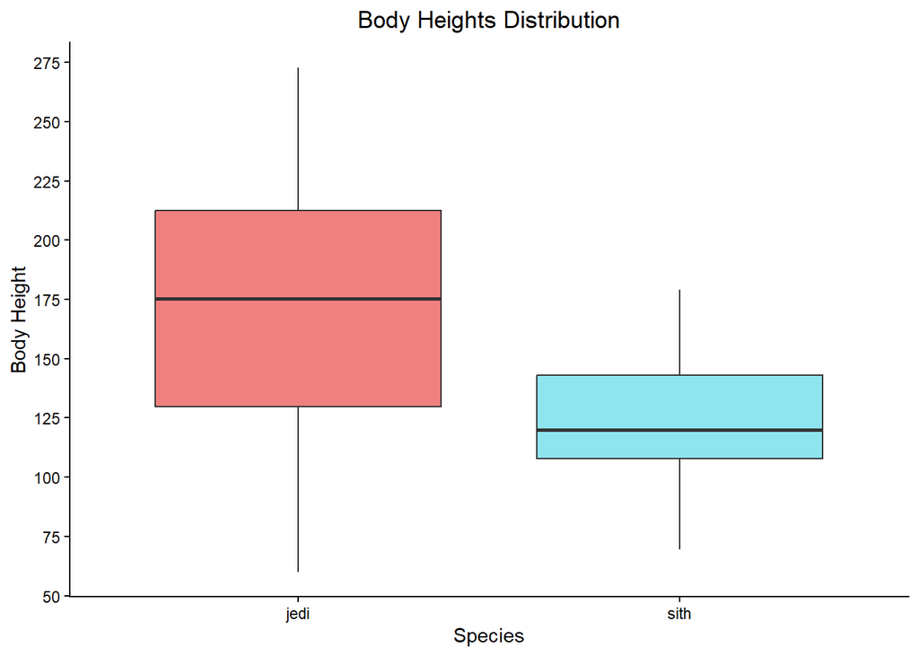

```r
# Make the boxplot using ggplot
ggplot(magic_guys, aes(x = species, y = length, fill = species)) +
  geom_boxplot() +
  scale_fill_manual(
    values = c(
      "jedi" = "lightcoral",
      "sith" = "cadetblue2")
  ) +
  scale_y_continuous(
  breaks = seq(50, 275, by = 25)   # set the y axis
  ) +
  labs(
    x = "Species",
    y = "Body Height",
    title = "Body Heights Distribution"
  ) +
  theme_classic() +
  theme(
  plot.title = element_text(hjust = 0.5),
  legend.position = "none")
```

Different formats are useful for different applications.

‘png’ file is useful for inserting figures into presentations or documents. However, the quality may be reduced if enlarged, especially if saved in lower resolution (DPI).

On the other hand, ‘pdf’ file can usually be enlarged without losing the sharpness of the picture. It is suitable for publications and printing.

‘svg’ is particulary useful for web use. It also stores the elements as vectors, making it editable. The figure can also be enlarged without decreasing its quality.

# 2. microarray_data.tab dataset

```r
# Loading microarray_data.tab dataset
microarray_data <- read.delim("microarray_data.tab")
```

1. Size of the matrix

```r
# Checking the dimension
dim(microarray_data)
```

```
## [1]  553 1000
```

The result shows that the matrix consists of 553 rows and 1,000 columns.

2. Missing values per gene and visualization

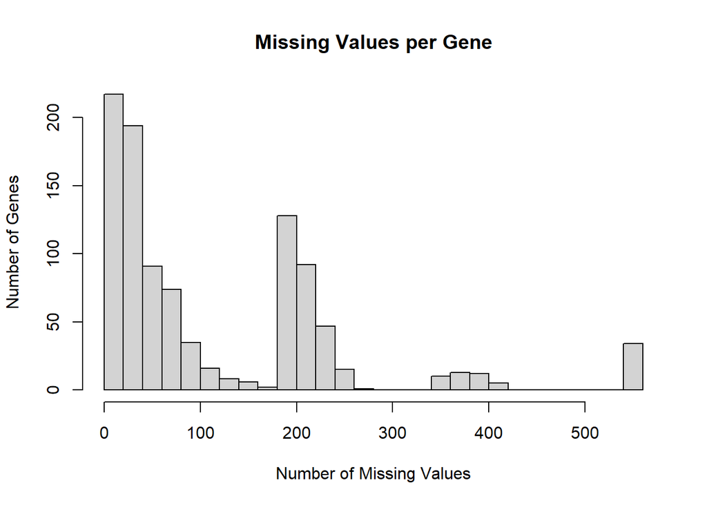

```r
# Calculating missing values per gene
missing_per_gene <- colSums(is.na(microarray_data))

# Visualization of missing values per gene using histogram
hist(missing_per_gene,
     main = "Missing Values per Gene",
     xlab = "Number of Missing Values",
     ylab = "Number of Genes",
     breaks = 30)
```

3. Genes which there are more than X% (X = 10%, 20%, 50%) missing values

```r
# Making a vector of percentages of missing values per gene
missing_percent <- (missing_per_gene / nrow(microarray_data)) * 100

# Obtaining genes with more than 10% missing values
names(missing_percent[missing_percent > 10])
```

```
##   [1] "g1"   "g2"   "g3"   "g4"   "g5"   "g10"  "g11"  "g12"  "g14"  "g15"
##  [11] "g16"  "g18"  "g21"  "g22"  "g23"  "g24"  "g25"  "g26"  "g28"  "g29"
##  [21] "g35"  "g36"  "g37"  "g38"  "g39"  "g40"  "g41"  "g42"  "g44"  "g45"
##  [31] "g46"  "g47"  "g48"  "g49"  "g50"  "g51"  "g52"  "g53"  "g54"  "g55"
##  [41] "g56"  "g57"  "g58"  "g59"  "g60"  "g61"  "g62"  "g63"  "g64"  "g65"
##  [51] "g66"  "g67"  "g68"  "g69"  "g70"  "g71"  "g72"  "g73"  "g74"  "g75"
##  [61] "g76"  "g77"  "g78"  "g79"  "g80"  "g81"  "g82"  "g83"  "g84"  "g85"
##  [71] "g86"  "g87"  "g88"  "g89"  "g90"  "g91"  "g92"  "g93"  "g94"  "g95"
##  [81] "g96"  "g97"  "g98"  "g99"  "g100" "g101" "g102" "g103" "g104" "g105"
##  [91] "g106" "g107" "g108" "g109" "g110" "g111" "g112" "g113" "g114" "g115"
## [101] "g116" "g117" "g118" "g119" "g120" "g130" "g131" "g132" "g133" "g134"
## [111] "g135" "g136" "g137" "g138" "g139" "g140" "g142" "g147" "g148" "g151"
## [121] "g152" "g153" "g154" "g155" "g156" "g157" "g158" "g159" "g160" "g165"
## [131] "g171" "g172" "g173" "g174" "g175" "g176" "g177" "g178" "g179" "g180"
## [141] "g194" "g196" "g200" "g204" "g210" "g221" "g223" "g233" "g239" "g241"
```

[output cut: 38 more lines]

```r
# Obtaining genes with more than 20% missing values
names(missing_percent[missing_percent > 20])
```

```
##   [1] "g1"   "g14"  "g18"  "g21"  "g22"  "g24"  "g25"  "g26"  "g29"  "g39"
##  [11] "g40"  "g41"  "g48"  "g51"  "g52"  "g53"  "g54"  "g55"  "g56"  "g57"
##  [21] "g58"  "g59"  "g60"  "g61"  "g62"  "g63"  "g64"  "g65"  "g66"  "g67"
##  [31] "g68"  "g69"  "g70"  "g71"  "g72"  "g73"  "g74"  "g75"  "g76"  "g77"
##  [41] "g78"  "g79"  "g80"  "g81"  "g82"  "g83"  "g84"  "g85"  "g86"  "g87"
##  [51] "g88"  "g89"  "g90"  "g91"  "g92"  "g93"  "g94"  "g95"  "g96"  "g97"
##  [61] "g98"  "g99"  "g100" "g101" "g102" "g103" "g104" "g105" "g106" "g107"
##  [71] "g108" "g109" "g110" "g111" "g112" "g113" "g114" "g115" "g116" "g117"
##  [81] "g118" "g119" "g120" "g130" "g131" "g132" "g133" "g134" "g135" "g136"
##  [91] "g137" "g138" "g139" "g140" "g142" "g147" "g148" "g151" "g152" "g153"
## [101] "g154" "g155" "g156" "g157" "g158" "g159" "g160" "g165" "g171" "g172"
## [111] "g173" "g174" "g175" "g176" "g177" "g178" "g179" "g180" "g196" "g200"
## [121] "g204" "g210" "g233" "g252" "g260" "g290" "g297" "g301" "g321" "g329"
## [131] "g332" "g333" "g334" "g335" "g344" "g351" "g352" "g353" "g354" "g355"
## [141] "g356" "g357" "g358" "g359" "g360" "g361" "g362" "g363" "g364" "g365"
```

[output cut: 23 more lines]

```r
# Obtaining genes with more than 50% missing values
names(missing_percent[missing_percent > 50])
```

```
##  [1] "g18"  "g48"  "g55"  "g58"  "g60"  "g66"  "g73"  "g79"  "g83"  "g91"
## [11] "g93"  "g94"  "g99"  "g105" "g109" "g132" "g135" "g137" "g138" "g172"
## [21] "g260" "g290" "g301" "g329" "g352" "g355" "g362" "g363" "g368" "g383"
## [31] "g388" "g389" "g390" "g391" "g406" "g417" "g431" "g432" "g440" "g461"
## [41] "g462" "g498" "g519" "g527" "g531" "g532" "g538" "g572" "g575" "g576"
## [51] "g577" "g585" "g615" "g619" "g663" "g669" "g751" "g753" "g766" "g768"
## [61] "g788" "g802" "g804" "g838" "g851" "g854" "g864" "g892" "g893" "g898"
## [71] "g919" "g932" "g971" "g980"
```

4. Replacing the missing values by the average expression value for the particular gene

```r
# Obtaining means for each gene
gene_means <- colMeans(microarray_data, na.rm = TRUE)
```

From summary, there are 34 genes with no value at all (NA)

```r
summary(gene_means)
```

```
##     Min.  1st Qu.   Median     Mean  3rd Qu.     Max.      NAs
## -0.83508 -0.21965 -0.10112 -0.08016  0.03616  1.38096       34
```

Therefore, these 34 genes will be skipped.

```r
# Make a duplicate of data to be imputed
imputed_data <- microarray_data

# for loop is used to repeat task (replacing NA with the gene mean) for all genes
for (gene in names(imputed_data)) {     # obtain each gene from the data
  if (is.na(gene_means[gene])) {        # if the mean is missing, it will be skipped
  next
}
  imputed_data[[gene]][                             # obtain all values of gene from the data
  is.na(imputed_data[[gene]])] <- gene_means[gene]  # obtain gene with NA and replace with mean
}
```

To check the imputed data:

```r
sum(is.na(imputed_data))
```

```
## [1] 18802
```

```r
sum(is.na(microarray_data))
```

```
## [1] 117826
```

Now, there are less NA values in the imputed data compared to the original microarray data. The remaining NA values are from the 34 genes which do not have means and therefore, skipped from imputation.

If we take one gene example:

```r
summary(microarray_data$g1)
```

```
##     Min.  1st Qu.   Median     Mean  3rd Qu.     Max.      NAs
## -6.21000 -0.38950  0.08700  0.02548  0.51600  4.08700      130
```

```r
summary(imputed_data$g1)
```

```
##     Min.  1st Qu.   Median     Mean  3rd Qu.     Max.
## -6.21000 -0.17600  0.02548  0.02548  0.35900  4.08700
```

The summary shows that there are 130 NA values in the original microarray data of g1, but no more NA values in the imputed data.

This confirms the imputation is successful.

# 3. Visualizing the CO2 dataset to give us deeper understanding

To further understand the dataset, I made a plot which could give us information on the comparison of the CO2 uptake trend between Quebec and Mississippi plants, as well as chilled and non-chilled plants.

Each measurement is represented as individual data point and a line graph is also added to give us visualization of the trend.

The following script is used to make the plot:

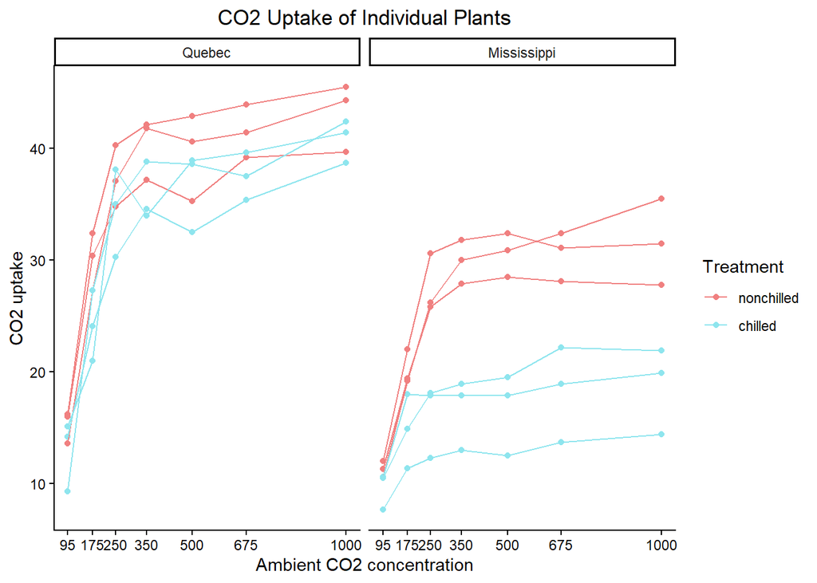

```r
# Make the plot
ggplot(CO2, aes(
  x = conc,
  y = uptake,
  color = Treatment,
  group = Plant
)) +
  geom_point() +
  geom_line() +
  facet_wrap(~ Type) + # create two panels based on Type
  labs(
    title = "CO2 Uptake of Individual Plants",
    x = "Ambient CO2 concentration",
    y = "CO2 uptake",
    color = "Treatment"
  ) +
  scale_x_continuous(
    breaks = c(95, 175, 250, 350, 500, 675, 1000)
  ) +
  scale_color_manual(values = c(
    "nonchilled" = "lightcoral",
    "chilled" = "cadetblue2")
    ) +
    theme_classic() +
  theme(
  plot.title = element_text(hjust = 0.5))
```

Based on the plot, we are now able to see that the CO2 uptake generally increase with the CO2 concentration with a sharp increase from CO2 concentration of 95 to 175. However, it is notable that in non-chilled Quebec plants, two out of three plants show a decrease of CO2 uptake at CO2 concentration of 500, before the CO2 uptake increase again along with the CO2 concentration.

Another notable observation is chilled plants tend to generally have lower CO2 uptake compared to non-chilled plants. CO2 uptake of Mississippi plants, both chilled and non-chilled, are also lower compared to Quebec plants.